# Understanding US Presidential Speeches from 1900 till Today

Speech Topics and Semantic Similairty Over Time

Author

Harman Singh

# 1 Introduction

Much criticism of then-Candidate, now-President, Donald Trump has centered on him being unfit for the Office of President of the United States, or his “unpresidentiality”. Some of this criticism also emerges from Donald Trump’s rhetorical style, which has also been deemed “unpresidential”. But what does “Presidentiality” mean? Are there common traits, character qualities, rhetorical styles, or other elements that are common to US Presidents?

While these are valuable and interesting questions to ask, this memo aims to answer two questions related to these questions in detail; namely, whether there **are certain topics that are common to US Presidential speeches over time, and whether US Presidents have given speeches and addresses in a way similar to each other?**

# 2 Data

In order to answer these two questions, I use data on Presidential Speeches and Addresses available publicly from the Miller Center at the University of Virginia. Their data on Presidential Speeches is a collection of addresses and speeches, in text form, given by US Presidents from George Washington’s time till the present presidency. While the collection is *not* exhaustive, it is extensive and contains over 1,000 speeches within it. The data is available to the public in a JSON file format, encoded with a textual transcription of the speech, the date the speech was given, its corresponding President, and title.

# 3 Methodology

## 3.1 Selection of the Data

To account for temporal shifts in American society and the realignment in domestic and foreign policy goals, I decided to limit the data to only include speeches from Presidents from the 20th Century on - as such, beginning from Theodore Roosevelt’s Presidency in 1901 onward. This method allows us to capture the historical trend of topics relevant today without skewing the data towards topics that may have been more relevant pre-20th Century but are less so today. In such, our data gains temporal breadth while maintaining relevance for our current world.

Additionally, only speeches given by the President while they were in office are kept within the dataset, and any speeches given while holding other political offices or while campaigning for the Presidency are removed to maintain consistency across for all Presidents within the dataset.

Finally, only minimal text cleaning operations were applied to the speeches, in order to maintain semantic and contextual coherence of the speeches and to optimize the text available for the topic modelling algorithm.

## 3.2 Analysis of Topics In Speeches

### BERTopic Analysis

The first method I used is BERTopic Analysis to identify which topics were found within the speeches. BERTopic is a machine learning technique that groups similar texts into topics by analyzing patterns in language. It uses advanced language models to understand meaning, then clusters related texts together. This helps identify key themes across large sets of documents, like my speeches, without needing manual categorization.

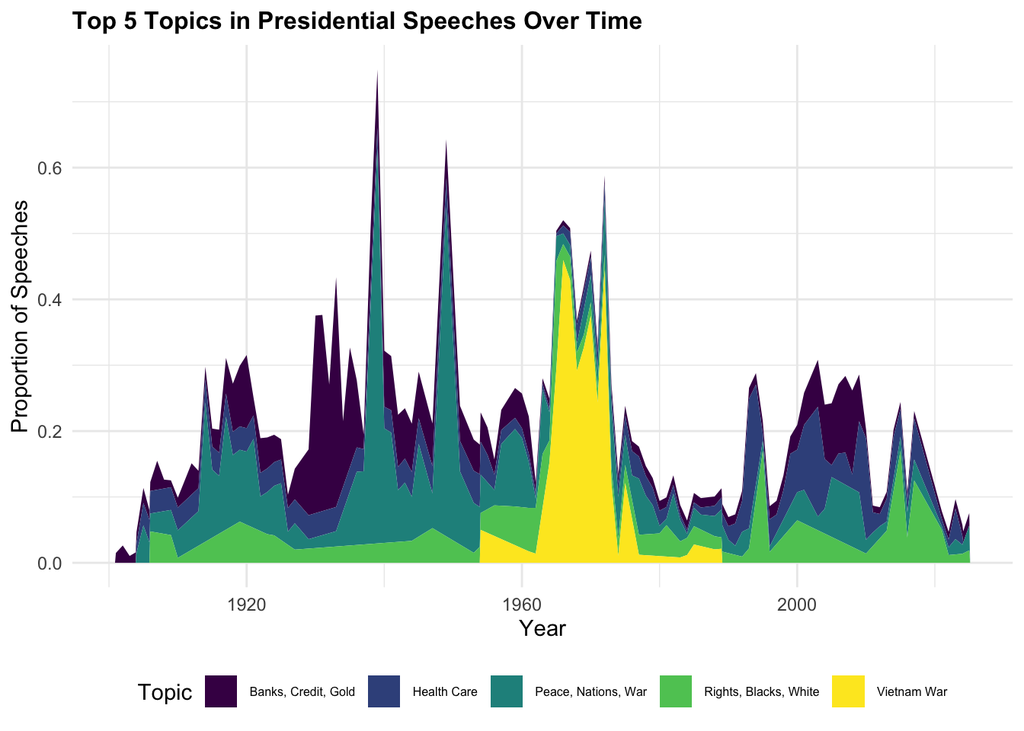

This graph shows the top five topics that were identified by BERTopic from the speeches, graphed year over year on the x-axis. The y-axis shows the proportion of speeches in each year in which the following topics were identified. Proportion helps account for any offsets within our dataset in which some years had more speeches and others less so.

The graph below follows the same x and y-axis outline as above, only this time is split to show each topic’s prevalence individually.

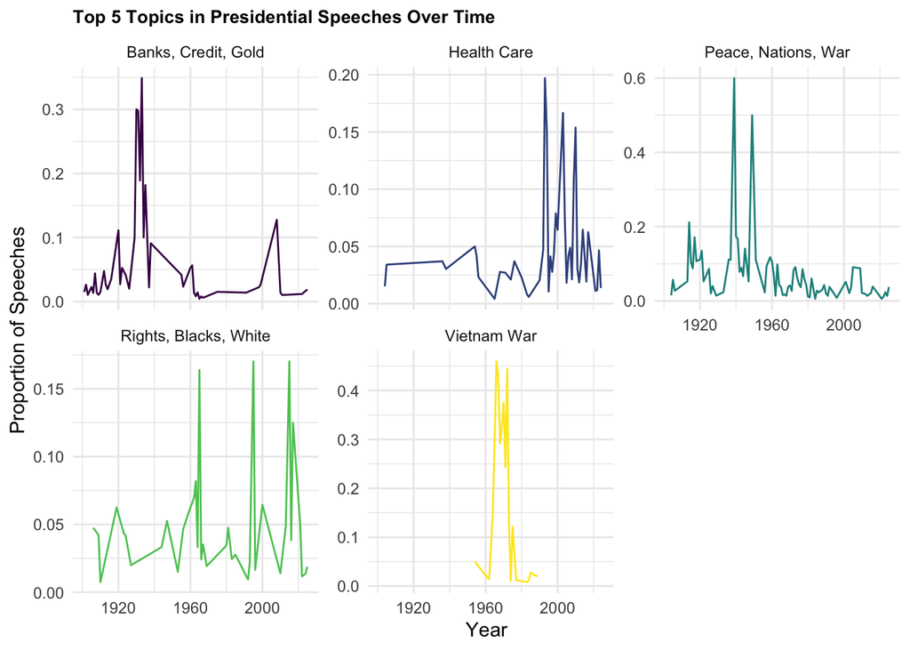

Visualization of these graphs helps reveal important lessons and information:

- **The top five topics** in US presidential speeches of the 20th and 21st Century concern the topics of:
  - Banking and Gold
  - Health Care
  - War and Peace
  - Civil Rights and Racial Discourse
  - The Vietnam War
- **Topics spoken about** by US Presidents are contingent upon the changes within the domestic or international political systems.
  - For example, discussions on Banking and Gold peaked around the Great Depression, when the US left the Gold Standard, and the 2008 Financial but declines at other times.
  - Discussion on Vietnam were not significantly prevalent before the Vietnam War nor were they significantly present after.
- **The topic of** Race and Racial/Civil Equality and War and Peace are consistently recurring over the years in the United States, showing that while both conflicts have persisted at the forefront of discussions of the highest Office in the United States, concerns of international wars and peace are more prevelant and important to US Presidents.

### Cosine Similarity

The cosine angle $\cos(\theta)$ between two vectors/documents $a$ and $b$ can be defined as:

$$\cos(\theta) = \frac{a \cdot b}{\|a\| \|b\|}$$
where ${\|a\|}$ and ${\|b\|}$ are the magnitudes of vectors $a$ and $b$.

#### Cosine Similarity with Word Embeddings

Cosine similarity is a technique used to measure how similar two pieces of text are by comparing the angle between them in a multi-dimensional space. When combined with word embeddings — mathematical representations of words that capture their meanings and contexts — this method allows us to compare texts based on their *semantic similarity*. Word embeddings generated by BERTopic understands the nuances of language beyond simply matching words. This is useful for understanding the *meaning* of sentences.

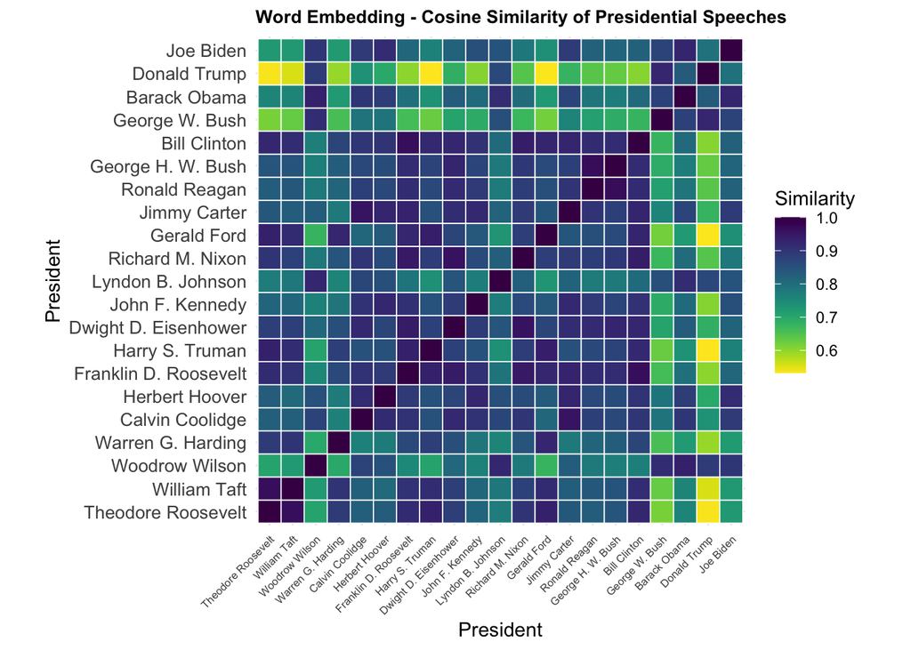

This graph shows the cosine similarity score of each Presidential speech using the word embeddings method. A darker square equates to a higher score and a lighter score signifies a lower score. Presidents are listed on both the x and y axes in an ascending chronological order, and scores are compared in comparison to each other. The black squares running up diagonally (left-right) signify a score of 1.0, meaning that square is that of the President in question.

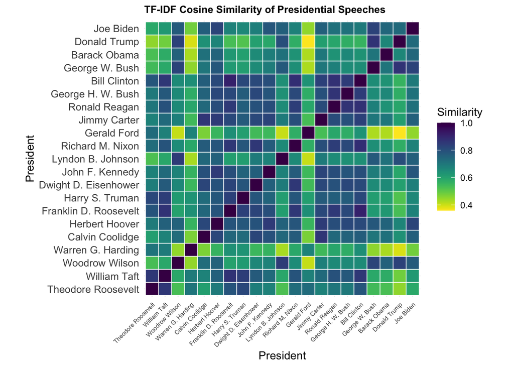

# 4 Conclusion

This analysis reveals deeper insights into the nature of the US Presidency, particularly the public speaking aspect of the highest office of the land.

By applying BERTopic Analysis and Cosine Similarity using Word Embedding and TF-IDF, this study reveals three main outcomes.

Firstly, that the proportion of *topic prevalence in Presidential speeches is time dependent* – it fluctuates in accordance with changes in the political spheres, either global or domestic.

Secondly, both with *content and vocabulary*, there is a *similarity* between Presidents from Coolidge *until Clinton*, after which there is a break and a set of new similarities that begin.

# 5 Appendix

This is a technical appendix for the operations performed to create this memo.

## 5.1 Part 1: Loading the Data

```python
import json as json

with open('speeches.json', 'r') as file:
  speeches = json.load(file)
```

```python
import pandas as pd
df = pd.json_normalize(speeches)
```

## 5.2 Part 2: Cleaning and Organizing the Text

```python
keep_presidents = [
    "Theodore Roosevelt", "William Taft", "Woodrow Wilson",
    "Warren G. Harding", "Calvin Coolidge", "Herbert Hoover",
    "Franklin D. Roosevelt", "Harry S. Truman", "Dwight D. Eisenhower",
    "John F. Kennedy", "Lyndon B. Johnson", "Richard M. Nixon",
    "Gerald Ford", "Jimmy Carter", "Ronald Reagan",
    "George H. W. Bush", "Bill Clinton", "George W. Bush",
    "Barack Obama", "Donald Trump", "Joe Biden"
]

df_new = df[df["president"].isin(keep_presidents)]

df_new = df_new.drop(['doc_name', 'title'], axis=1)

df_new.sort_values("date", inplace=True)
df_new.reset_index(drop=True, inplace=True)
```

```python
president_terms = {
    "Theodore Roosevelt": ("1901-09-14", "1909-03-04"),
    "William Taft": ("1909-03-04", "1913-03-04"),
    "Woodrow Wilson": ("1913-03-04", "1921-03-04"),
    "Warren G. Harding": ("1921-03-04", "1923-08-02"),
    "Calvin Coolidge": ("1923-08-02", "1929-03-04"),
    "Herbert Hoover": ("1929-03-04", "1933-03-04"),
    "Franklin D. Roosevelt": ("1933-03-04", "1945-04-12"),
    "Harry S. Truman": ("1945-04-12", "1953-01-20"),
    "Dwight D. Eisenhower": ("1953-01-20", "1961-01-20"),
    "John F. Kennedy": ("1961-01-20", "1963-11-22"),
    "Lyndon B. Johnson": ("1963-11-22", "1969-01-20"),
    "Richard M. Nixon": ("1969-01-20", "1974-08-09"),
    "Gerald Ford": ("1974-08-09", "1977-01-20"),
    "Jimmy Carter": ("1977-01-20", "1981-01-20"),
    "Ronald Reagan": ("1981-01-20", "1989-01-20"),
    "George H. W. Bush": ("1989-01-20", "1993-01-20"),
    "Bill Clinton": ("1993-01-20", "2001-01-20"),
    "George W. Bush": ("2001-01-20", "2009-01-20"),
    "Barack Obama": ("2009-01-20", "2017-01-20"),
    "Donald Trump": ("2017-01-20", "2021-01-20"),
    "Joe Biden": ("2021-01-20", "2025-01-20"),
    "Donald Trump": ("2024-01-20", "2025-04-27"),
}
```

```python
df_new['date'] = pd.to_datetime(df_new['date'], format='ISO8601', utc=True, errors='coerce')
df_new = df_new.dropna(subset=['date'])
df_new['date'] = df_new['date'].dt.date
```

```python
for pres, (start, end) in president_terms.items():
    start_date = pd.to_datetime(start).date()
    end_date = pd.to_datetime(end).date() if end else pd.Timestamp.today().date()
    president_terms[pres] = (start_date, end_date)
```

```python
def was_president_at_time(row):
    pres = row['president']
    date = row['date']

    if pres in president_terms:
        start, end = president_terms[pres]
        return start <= date <= end
    return False


df_proper = df_new[df_new.apply(was_president_at_time, axis=1)].reset_index(drop=True)
```

## 5.3 Part 3: BERTopic Analysis

```python
import pandas as pd
from sklearn.feature_extraction.text import CountVectorizer
from gensim.models.ldamodel import LdaModel
from gensim import corpora
from nltk.corpus import stopwords
from nltk.stem.porter import PorterStemmer
import numpy as np
```

```python
def clean_text(text):
    text = text.replace('\n', ' ')
    return text.strip()
df_proper['cleaned_text'] = df_proper['transcript'].apply(clean_text)
```

```python
def chunk_text(text, max_words=300):
    words = text.split()
    return [' '.join(words[i:i+max_words]) for i in range(0, len(words), max_words)]

df_proper['chunks'] = df_proper['cleaned_text'].apply(chunk_text)

docs_chunked = [chunk for chunks in df_proper['chunks'] for chunk in chunks]
```

```python
df_proper = df_proper.reset_index(drop=True)
df_proper['speech_id'] = df_proper.index + 1
```

```python
import os
os.environ["TOKENIZERS_PARALLELISM"] = "false"

import contextlib
from sentence_transformers import SentenceTransformer
from bertopic import BERTopic
from umap import UMAP
umap_model = UMAP(random_state=42)

#embedding_model = SentenceTransformer("all-MiniLM-L6-v2")
#vectorizer_model = CountVectorizer(stop_words="english")

topic_model = BERTopic(
  #embedding_model=embedding_model,
  #vectorizer_model=vectorizer_model,
  calculate_probabilities=True,
  verbose=False,
  umap_model = umap_model,
  #top_n_words=7,
  #nr_topics="auto",
)

topics, probs = topic_model.fit_transform(docs_chunked)
```

```python
topic_info = topic_model.get_topic_info()[['Topic', 'Count', 'Name', 'Representation']]

topic_info_simple = topic_info[["Topic", 'Count', "Representation"]]

topic_info_simple['Representation'] = topic_info_simple['Representation'].apply(lambda x: ' '.join(dict.fromkeys(x).keys()))

frequency_table = pd.DataFrame(topic_info_simple)
```

```python
chunked_data = []

for idx, row in df_proper.iterrows():
    chunks = chunk_text(row['cleaned_text'], max_words=300)
    for chunk in chunks:
        chunked_data.append({
            "original_speech_id": row['speech_id'],
            "president": row['president'],
            "date": row['date'],
            "transcript": chunk
        })


df_chunked = pd.DataFrame(chunked_data)
```

```python
df_chunked['topic'] = topics
```

```python
excluded_topics = [-1]

def reassign_topic(topic, prob_row):
    if topic in excluded_topics:
        sorted_indices = np.argsort(prob_row)[::-1]
        for idx in sorted_indices:
            if idx not in excluded_topics:
                return idx
        return topic
    else:
        return topic

df_chunked["topic"] = [
    reassign_topic(t, p) for t, p in zip(df_chunked["topic"], probs)
]
```

```python
topic_labels = {
    row["Topic"]: row["Representation"]
    for _, row in topic_info_simple.iterrows()
}

df_chunked["topic_label"] = df_chunked["topic"].map(topic_labels)
df_chunked['year'] = pd.to_datetime(df_chunked['date']).dt.year
```

### 5.3.1 Data Visualization

```python
top_5_topics = df_chunked['topic'].value_counts().head(5).index
df_top_5 = df_chunked[df_chunked['topic'].isin(top_5_topics)]
```

```python
df_count_by_year = df_top_5.groupby(['year', 'topic']).size().reset_index(name='count')

df_total_by_year = df_chunked.groupby('year').size().reset_index(name='total')
df_count_by_year = pd.merge(df_count_by_year, df_total_by_year, on='year')

df_count_by_year['proportion'] = df_count_by_year['count'] / df_count_by_year['total']
df_count_by_year['topic_labels'] = df_count_by_year["topic"].map(topic_labels)
```

```python
manual_labels = {
  0: "Vietnam War",
  1: "Health Care",
  7: "Banks, Credit, Gold",
  2: "Peace, Nations, War",
  3: "Rights, Blacks, White",

}

df_count_by_year['manual_labels'] = df_count_by_year["topic"].map(manual_labels)
```

```r
library(ggplot2)
count_by_year <- reticulate::py$df_count_by_year

ggplot(count_by_year, aes(x = year, y = proportion, fill = manual_labels)) +
  geom_area() +
  theme_minimal() +
  labs(title = "Top 5 Topics in Presidential Speeches Over Time",
       x = "Year",
       y = "Proportion of Speeches",
       fill = "Topic") +
  scale_fill_viridis_d() +
  theme(plot.title = element_text(size = 12,face='bold'),
        legend.position = "bottom",
        legend.text = element_text(size = 6))
```

```r
ggplot(count_by_year, aes(x = year, y = proportion)) +
  geom_line(aes(color = manual_labels)) +
  facet_wrap(~ manual_labels, scales = "free_y") +
  theme_minimal() +
  labs(title = "Top 5 Topics in Presidential Speeches Over Time",
       x = "Year",
       y = "Proportion of Speeches",
       color = "Topic") +
  scale_color_viridis_d() +
  theme(
    legend.position = "none",
    plot.title = element_text(size = 10,face='bold')
  )
```

## 5.4 Part 4: Cosine Similarity

### 5.4.1 Word Embedding

```python
topics, probs = topic_model.transform(df_chunked["transcript"].tolist())
embeddings = topic_model._extract_embeddings(df_chunked["transcript"].tolist(), method="document")

df_chunked["embedding"] = list(embeddings)
```

```python
president_embedding = df_chunked.groupby("president")["embedding"].apply(
    lambda emb_list: np.mean(np.vstack(emb_list), axis=0)
    )
```

```python
from sklearn.metrics.pairwise import cosine_similarity

X = np.vstack(president_embedding.values)
cosine_similarity_matrix = cosine_similarity(X)
```

```python
presidents = president_embedding.index.tolist()

similarity_df = pd.DataFrame(cosine_similarity_matrix, index=keep_presidents, columns=keep_presidents)
```

### 5.4.2 Word Embedding Visualization

```r
library(reshape2)
library(viridis)


similarity_matrix <- reticulate::py$similarity_df
similarity_matrix <- as.matrix(similarity_matrix)
melted_matrix <- melt(similarity_matrix, varnames = c("president_1", "president_2"))

ggplot(melted_matrix, aes(x = president_1, y = president_2, fill = value)) +
  geom_tile(color = "white", linewidth = 0.3) +
  scale_fill_viridis(
    option = "viridis",  # Try "magma", "plasma", or "inferno" for other variants
    direction = -1,
    limits = c(min(melted_matrix$value), max(melted_matrix$value))
  ) +
  theme_minimal() +
  theme(
    axis.text.x = element_text(angle = 45, hjust = 1, size = 6),
    axis.text.y = element_text(size = 10),
    legend.position = "right",
    plot.title = element_text(size = 10,face='bold')

  ) +
  labs(
    x = "President",
    y = "President",
    title = "Word Embedding - Cosine Similarity of Presidential Speeches",
    fill = "Similarity"
  ) +
  coord_fixed()
```

### 5.4.3 TF-IDF Cosine Similarity

```python
from sklearn.feature_extraction.text import TfidfVectorizer
from nltk.corpus import stopwords
import nltk
nltk.download('stopwords')
stop_words = set(stopwords.words('english'))

def remove_stopwords(text):
    words = text.split()
    filtered_words = [word for word in words if word.lower() not in stop_words]
    return " ".join(filtered_words)
```

```python
presidents_aggregated = df_proper.groupby('president')['cleaned_text'].apply(" ".join).reset_index()

presidents_aggregated['cleaned_text'] = presidents_aggregated['cleaned_text'].apply(remove_stopwords)

vectorizer = CountVectorizer()
president_dfm = vectorizer.fit_transform(presidents_aggregated['cleaned_text'])
```

```python
pres_cosine = cosine_similarity(president_dfm,president_dfm)

similarity_df_2 = pd.DataFrame(
    pres_cosine,
    index=keep_presidents,
    columns=keep_presidents
)
```

### 5.4.4 TF-IDF Visualization

```r
similarity_matrix_2 <- reticulate::py$similarity_df_2
similarity_matrix_2 <- as.matrix(similarity_matrix_2)
melted_matrix_2 <- melt(similarity_matrix_2, varnames = c("president_1", "president_2"))


ggplot(melted_matrix_2, aes(x = president_1, y = president_2, fill = value)) +
  geom_tile(color = "white", linewidth = 0.3) +
  scale_fill_viridis(
    option = "viridis",  # Try "magma", "plasma", or "inferno" for other variants
    direction = -1,
    limits = c(min(melted_matrix_2$value), max(melted_matrix_2$value))
  ) +
  theme_minimal() +
  theme(
    axis.text.x = element_text(angle = 45, hjust = 1, size = 6),
    axis.text.y = element_text(size = 10),
    legend.position = "right",
    plot.title = element_text(size = 10, face='bold')

  ) +
  labs(
    x = "President",
    y = "President",
    title = "TF-IDF Cosine Similarity of Presidential Speeches",
    fill = "Similarity"
  ) +
  coord_fixed()
```